# DIABETES CLASSIFICATION-EXPLORATORY DATA ANALYSIS

### SET THE ENVIRONMENT

◈ There are a few lines of code that you'll need to run at the top of every notebook to set up your coding environment.(Notice that it returns as output: Setup Complete.)

```python
import pandas as pd
import numpy as np
pd.plotting.register_matplotlib_converters()
import matplotlib.pyplot as plt
%matplotlib inline
import seaborn as sns
import plotly.express as px
from sklearn.model_selection import train_test_split
from sklearn.metrics import accuracy_score
import warnings
warnings.filterwarnings('ignore')
print("Setup Complete")
```

```
Setup Complete
```

### LOAD THE DATA FROM DATABASE

◈ First create a connection to the SQLite3 database using the connect() method from the sqlite3 library. We then use the read_sql_query() method from the pandas library to execute a SQL query against the database and load the resulting data into a Pandas DataFrame. The SELECT * FROM tablename query can be replaced with any valid SQL query that returns data from the database.Finally, we use the head() method to display the first few rows of the DataFrame.

```python
import sqlite3
data=pd.read_csv("E:\SEYAL\Vacation project\diabetes.csv",index_col='Pregnancies')
connection=sqlite3.connect("E:\SEYAL\Vacation project\diabetesdata.db")
data.to_sql('diabetes',connection,if_exists='replace')
data= pd.read_sql("SELECT * FROM diabetes ",connection)
print("Database Connected")
```

```
Database Connected
```

```python
data.head(10)
```

|  | Pregnancies | Glucose | BloodPressure | SkinThickness | Insulin | BMI | DiabetesPedigreeFunction | Age | Outcome |
| --- | --- | --- | --- | --- | --- | --- | --- | --- | --- |
| 0 | 6 | 148 | 72 | 35 | 0 | 33.6 | 0.627 | 50 | 1 |
| 1 | 1 | 85 | 66 | 29 | 0 | 26.6 | 0.351 | 31 | 0 |
| 2 | 8 | 183 | 64 | 0 | 0 | 23.3 | 0.672 | 32 | 1 |
| 3 | 1 | 89 | 66 | 23 | 94 | 28.1 | 0.167 | 21 | 0 |
| 4 | 0 | 137 | 40 | 35 | 168 | 43.1 | 2.288 | 33 | 1 |
| 5 | 5 | 116 | 74 | 0 | 0 | 25.6 | 0.201 | 30 | 0 |
| 6 | 3 | 78 | 50 | 32 | 88 | 31.0 | 0.248 | 26 | 1 |
| 7 | 10 | 115 | 0 | 0 | 0 | 35.3 | 0.134 | 29 | 0 |
| 8 | 2 | 197 | 70 | 45 | 543 | 30.5 | 0.158 | 53 | 1 |
| 9 | 8 | 125 | 96 | 0 | 0 | 0.0 | 0.232 | 54 | 1 |

### DATA CLEANING

```python
#data cleaning process
for col in ["Glucose", "BloodPressure", "SkinThickness", "Insulin", "BMI"]:
    mean = data[data[col] != 0][col].mean()
    std = data[data[col] != 0][col].std()

    values = data[col].values

    np.random.seed(23)

    for i, val in enumerate(values):
        if val == 0:
            values[i] = mean + std * (np.random.rand() * 2 - 1) * 1.2
    data[col] = pd.Series(values).astype(data[col].dtype)
```

```python
data.head(10)
```

|  | Pregnancies | Glucose | BloodPressure | SkinThickness | Insulin | BMI | DiabetesPedigreeFunction | Age | Outcome |
| --- | --- | --- | --- | --- | --- | --- | --- | --- | --- |
| 0 | 6 | 148 | 72 | 35 | 160 | 33.600000 | 0.627 | 50 | 1 |
| 1 | 1 | 85 | 66 | 29 | 282 | 26.600000 | 0.351 | 31 | 0 |
| 2 | 8 | 183 | 64 | 29 | 231 | 23.300000 | 0.672 | 32 | 1 |
| 3 | 1 | 89 | 66 | 23 | 94 | 28.100000 | 0.167 | 21 | 0 |
| 4 | 0 | 137 | 40 | 35 | 168 | 43.100000 | 2.288 | 33 | 1 |
| 5 | 5 | 116 | 74 | 40 | 93 | 25.600000 | 0.201 | 30 | 0 |
| 6 | 3 | 78 | 50 | 32 | 88 | 31.000000 | 0.248 | 26 | 1 |
| 7 | 10 | 115 | 72 | 35 | 76 | 35.300000 | 0.134 | 29 | 0 |
| 8 | 2 | 197 | 70 | 45 | 543 | 30.500000 | 0.158 | 53 | 1 |
| 9 | 8 | 125 | 96 | 23 | 208 | 32.744954 | 0.232 | 54 | 1 |

### DESCRIPTIVE INFORMATION:

- *data.columns* is an attribute that returns a list of the column labels (or names).
- *data.shape* is an attribute that returns a tuple representing the dimensions of a DataFrame. The tuple contains two values: the number of rows and the number of columns in the DataFrame.
- *data.info()* is a method that provides a summary of a Pandas DataFrame, including information about the data types, the number of non-null values, and the memory usage.
- *data.describe()* is a method that provides a summary of the statistics of a Pandas DataFrame, including the count, mean, standard deviation, minimum and maximum values, and quartiles.
- *data.var()* is a method that calculates the variance of the values in a Pandas DataFrame along a specified axis.

```python
list(data.columns)
```

```
['Pregnancies',
 'Glucose',
 'BloodPressure',
 'SkinThickness',
 'Insulin',
 'BMI',
 'DiabetesPedigreeFunction',
 'Age',
 'Outcome']
```

```python
data.shape
```

```
(768, 9)
```

```python
data.info()
```

```
<class 'pandas.core.frame.DataFrame'>
RangeIndex: 768 entries, 0 to 767
Data columns (total 9 columns):
 #   Column                    Non-Null Count  Dtype
---  ------                    --------------  -----
 0   Pregnancies               768 non-null    int64
 1   Glucose                   768 non-null    int64
 2   BloodPressure             768 non-null    int64
 3   SkinThickness             768 non-null    int64
 4   Insulin                   768 non-null    int64
 5   BMI                       768 non-null    float64
 6   DiabetesPedigreeFunction  768 non-null    float64
 7   Age                       768 non-null    int64
 8   Outcome                   768 non-null    int64
dtypes: float64(2), int64(7)
memory usage: 54.1 KB
```

```python
data.describe()
```

|  | Pregnancies | Glucose | BloodPressure | SkinThickness | Insulin | BMI | DiabetesPedigreeFunction | Age | Outcome |
| --- | --- | --- | --- | --- | --- | --- | --- | --- | --- |
| count | 768.000000 | 768.000000 | 768.000000 | 768.000000 | 768.000000 | 768.000000 | 768.000000 | 768.000000 | 768.000000 |
| mean | 3.845052 | 121.705729 | 72.371094 | 28.907552 | 152.865885 | 32.446890 | 0.471876 | 33.240885 | 0.348958 |
| std | 3.369578 | 30.481394 | 12.249431 | 9.632385 | 102.668104 | 6.896638 | 0.331329 | 11.760232 | 0.476951 |
| min | 0.000000 | 44.000000 | 24.000000 | 7.000000 | 13.000000 | 18.200000 | 0.078000 | 21.000000 | 0.000000 |
| 25% | 1.000000 | 99.750000 | 64.000000 | 22.000000 | 77.000000 | 27.500000 | 0.243750 | 24.000000 | 0.000000 |
| 50% | 3.000000 | 117.000000 | 72.000000 | 29.000000 | 134.500000 | 32.300000 | 0.372500 | 29.000000 | 0.000000 |
| 75% | 6.000000 | 141.000000 | 80.000000 | 36.000000 | 205.000000 | 36.600000 | 0.626250 | 41.000000 | 1.000000 |
| max | 17.000000 | 199.000000 | 122.000000 | 99.000000 | 846.000000 | 67.100000 | 2.420000 | 81.000000 | 1.000000 |

```python
data.var()
```

```
Pregnancies                    11.354056
Glucose                       929.115378
BloodPressure                 150.048551
SkinThickness                  92.782837
Insulin                     10540.739487
BMI                            47.563621
DiabetesPedigreeFunction        0.109779
Age                           138.303046
Outcome                         0.227483
dtype: float64
```

## EXPLORATORY DATA ANALYSIS

◈ Exploratory Data Analysis (EDA) is an approach to analyze the data using visual techniques. It is used to discover trends, patterns, or to check assumptions with the help of statistical summary and graphical representations.  
◈ The hist() function is used to create histograms.This method bins the data x and count.Here for each of the attributes in the dataset "data", a histogram is created.

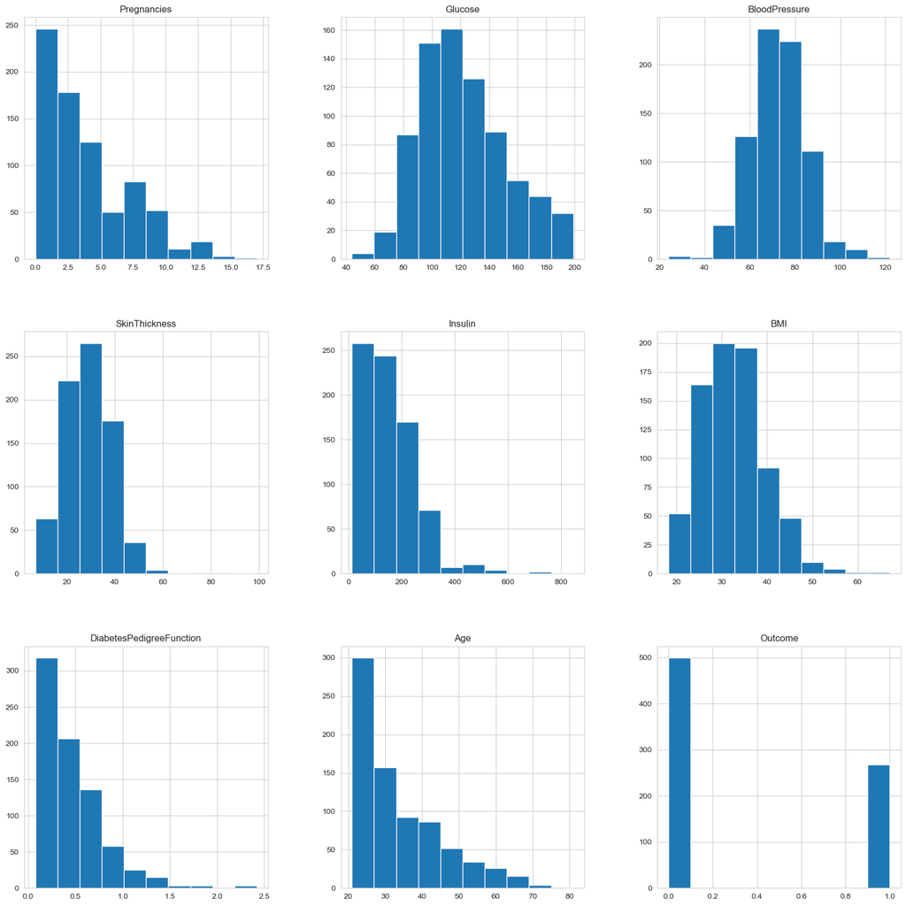

```python
# Exploratory Data analysis
p=data.hist(figsize = (20,20))
```

◈ A countplot is used to visualize the count of observations in a categorical variable. It is a type of bar plot that shows the frequency or number of occurrences of each category in the categorical variable.

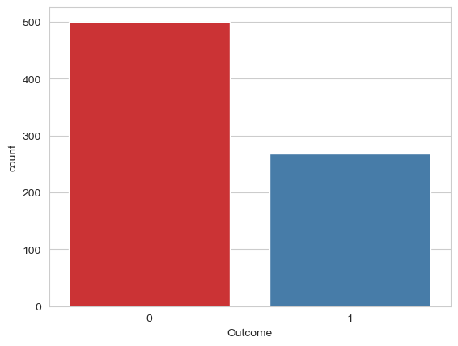

```python
sns.countplot(x='Outcome',data=data,palette ='Set1')
```

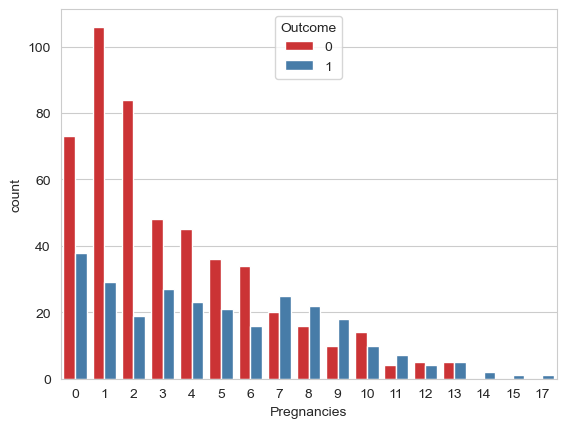

```python
sns.countplot(x ='Pregnancies', data = data,hue='Outcome',palette ='Set1')
```

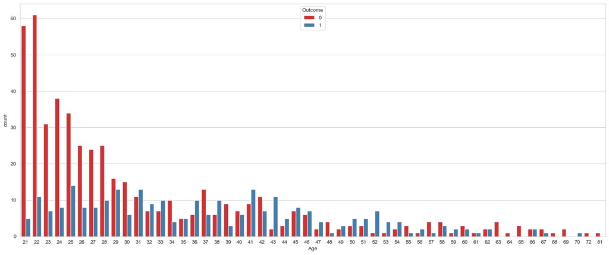

```python
plt.figure(figsize=(20,8))
sns.countplot(x ='Age',hue='Outcome',data = data,palette='Set1')
```

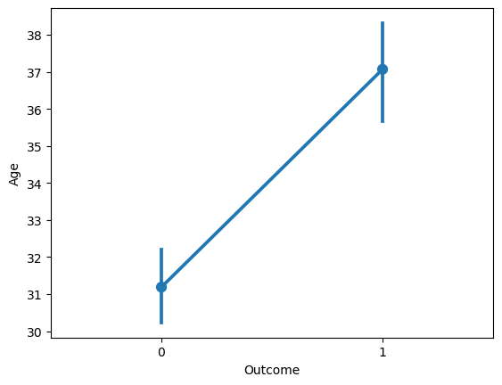

```python
sns.pointplot(x='Outcome', y= 'Age', data=data)
```

◈ Pair plot is used to understand the best set of features to explain a relationship between two variables or to form the most separated clusters. It also helps to form some simple classification models by drawing some simple lines or make linear separation in our dataset.

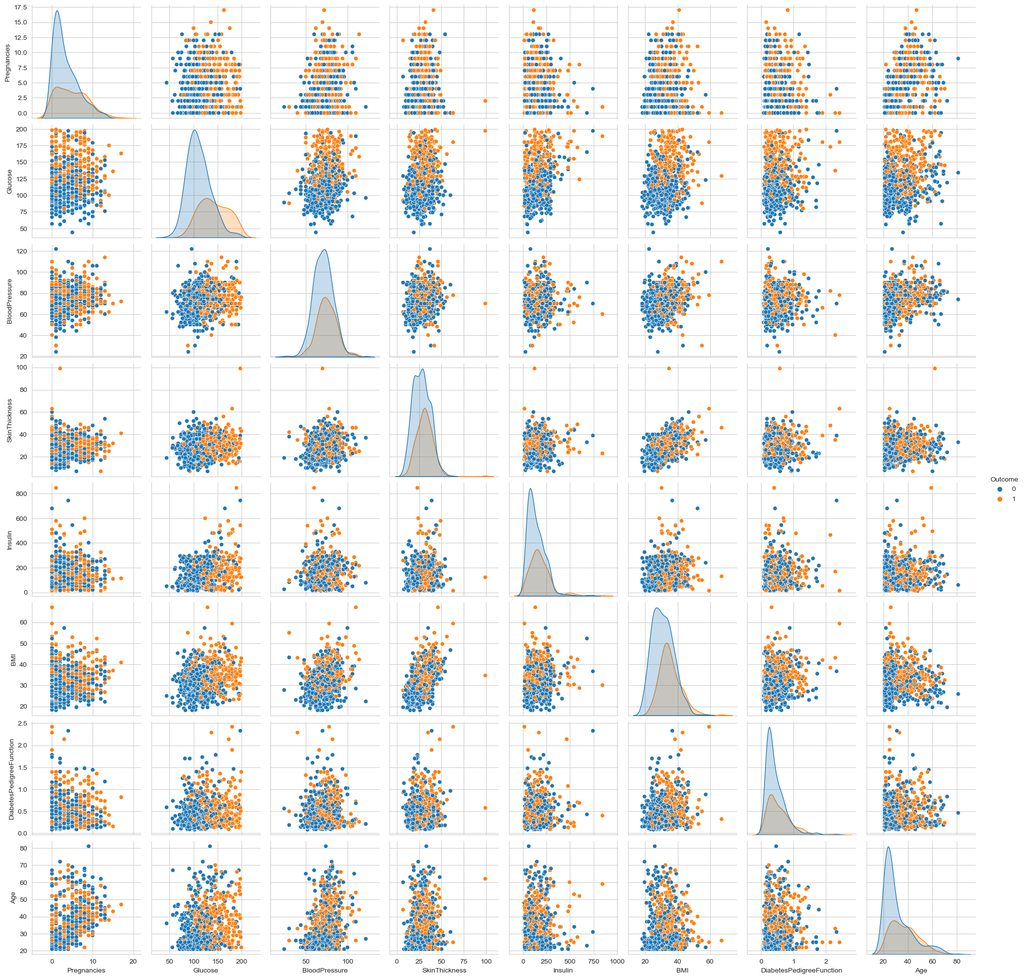

```python
sns.pairplot(data,hue='Outcome')
```

◈ lmplot is to visualize the relationship between two variables and to fit a linear regression model to the data to estimate the strength and direction of the relationship. ◈ The primary use cases for lmplot include: ▸ Exploring the relationship between two variables and determining whether there is a linear association between them ▸ Estimating the slope and intercept of a linear regression model and assessing the statistical significance of the relationship. ▸ Visualizing the goodness-of-fit of a linear regression model

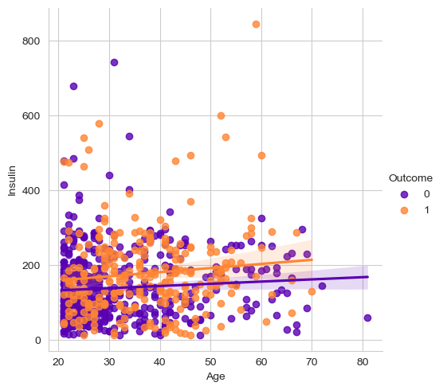

```python
pal=["#5900b3","#ff8533"]
sns.lmplot(x='Age',y='Insulin', hue='Outcome',data=data,palette=pal)
```

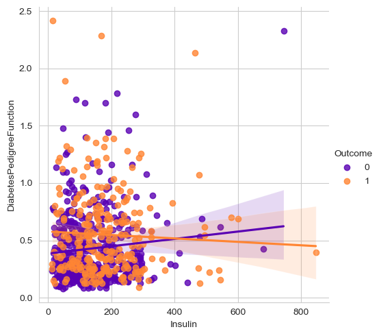

```python
pal=["#5900b3","#ff8533"]
sns.lmplot(x='Insulin',y='DiabetesPedigreeFunction', hue='Outcome',data=data,palette=pal)
```

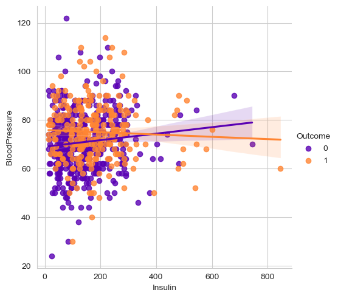

```python
pal=["#5900b3","#ff8533"]
sns.lmplot(x='Insulin',y='BloodPressure', hue='Outcome',data=data,palette=pal)
```

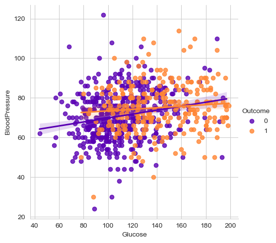

```python
pal=["#5900b3","#ff8533"]
sns.lmplot(x='Glucose',y='BloodPressure', hue='Outcome',data=data,palette=pal)
```

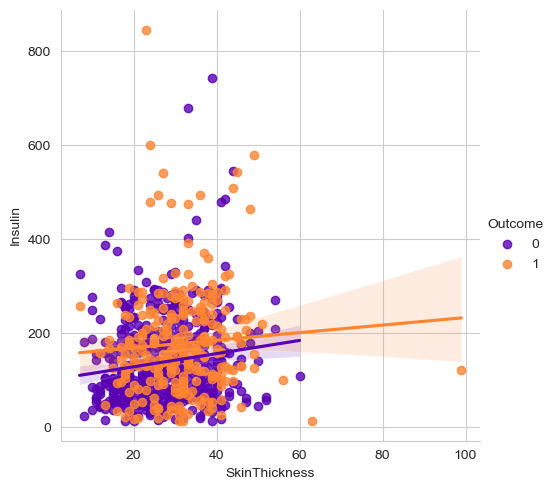

```python
pal=["#5900b3","#ff8533"]
sns.lmplot(x='SkinThickness', y= 'Insulin',hue='Outcome',data=data,palette=pal)
```

◈ A boxplot is a type of plot used to visualize the distribution of a numeric variable. The purpose of a boxplot is to show the median, quartiles, and extreme values of the data, and to identify any outliers or skewness in the data.

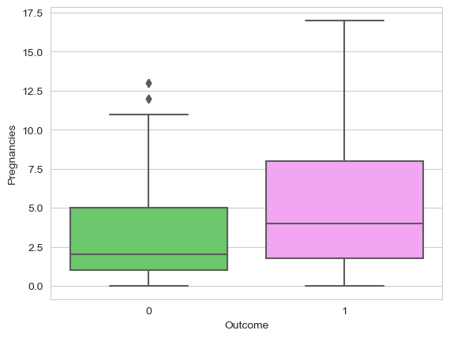

```python
pal=["#5cd65c","#ff99ff"]
sns.boxplot(x='Outcome',y='Pregnancies',data=data,palette=pal)
```

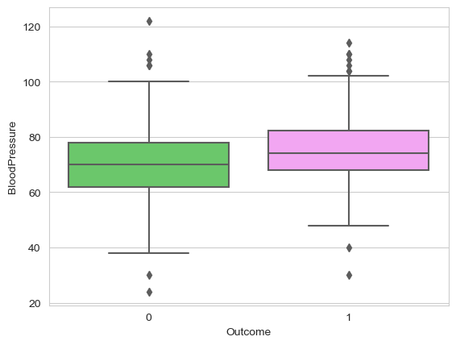

```python
pal=["#5cd65c","#ff99ff"]
sns.boxplot(x='Outcome',y='BloodPressure',data=data,palette=pal)
```

◈ kdeplot and histplot are two types of plots used to visualize the distribution of a numeric variable. Although both plots are similar in nature, they have some key differences in terms of their purpose and the information they convey.  
◈ Kdeplot, short for Kernel Density Estimate plot, is to provide a smooth estimate of the underlying distribution of the data, without binning the data into discrete categories. Histplot, short for Histogram plot,is to provide a visual representation of the distribution of the data, including the central tendency, variability, and shape.

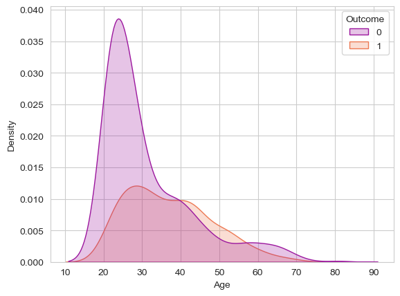

```python
sns.kdeplot(data=data,x='Age',hue='Outcome',fill=True, palette ='plasma')
```

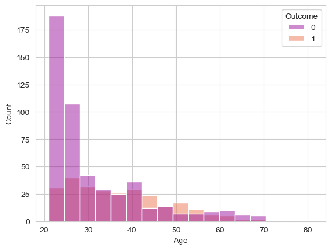

```python
sns.histplot(data=data, x='Age' ,hue='Outcome',palette='plasma')
```

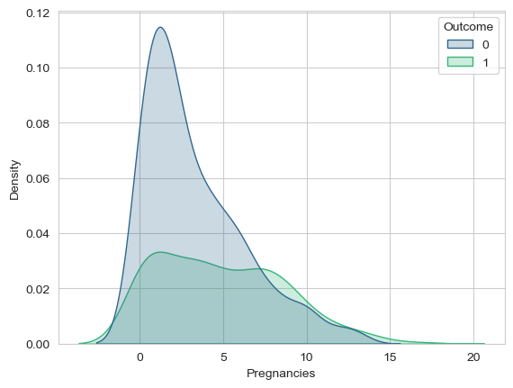

```python
sns.kdeplot(data=data,x='Pregnancies',hue='Outcome',fill=True,palette='viridis')
```

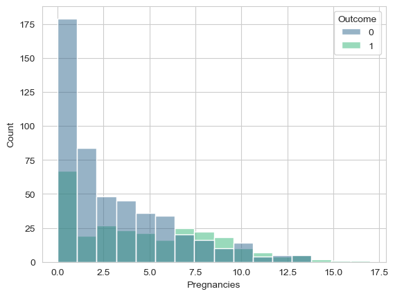

```python
sns.histplot(data=data, x='Pregnancies' ,hue='Outcome',palette='viridis')
```

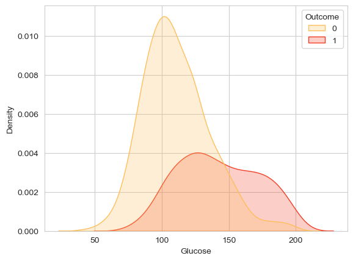

```python
sns.kdeplot(data=data,x='Glucose',hue='Outcome',fill=True,palette ='YlOrRd')
```

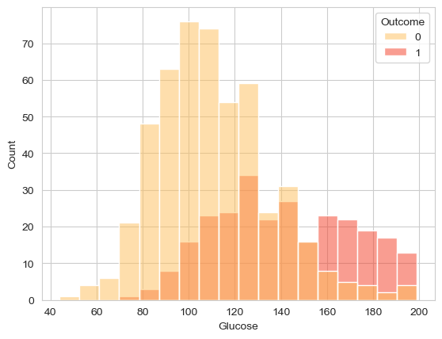

```python
sns.histplot(data=data, x='Glucose' ,hue='Outcome',palette='YlOrRd')
```

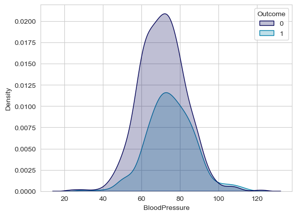

```python
sns.kdeplot(data=data,x='BloodPressure',hue='Outcome',fill=True,palette ='ocean')
```

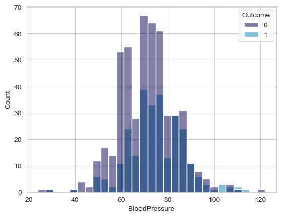

```python
sns.histplot(data=data, x='BloodPressure' ,hue='Outcome',palette='ocean')
```

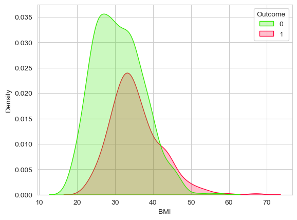

```python
sns.kdeplot(data=data,x='BMI',hue='Outcome',fill=True,palette ='prism')
```

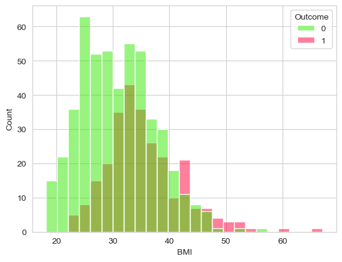

```python
sns.histplot(data=data, x='BMI' ,hue='Outcome',palette='prism')
```

### CORRELATION REPRESENTED USING HEATMAPS

◈ Variables within a dataset can be related for lots of reasons. It can be useful in data analysis and modeling to better understand the relationships between variables. The statistical relationship between two variables is referred to as their correlation. ◈ A correlation could be positive, meaning both variables move in the same direction, or negative, meaning that when one variable’s value increases, the other variables’ values decrease. Correlation can also be neural or zero, meaning that the variables are unrelated.

```python
data.corr()
```

|  | Pregnancies | Glucose | BloodPressure | SkinThickness | Insulin | BMI | DiabetesPedigreeFunction | Age | Outcome |
| --- | --- | --- | --- | --- | --- | --- | --- | --- | --- |
| Pregnancies | 1.000000 | 0.125034 | 0.215841 | 0.074514 | 0.052792 | 0.021695 | -0.033523 | 0.544341 | 0.221898 |
| Glucose | 0.125034 | 1.000000 | 0.218054 | 0.175655 | 0.339175 | 0.228435 | 0.135504 | 0.263083 | 0.488385 |
| BloodPressure | 0.215841 | 0.218054 | 1.000000 | 0.167552 | 0.072928 | 0.270853 | -0.003553 | 0.328401 | 0.162582 |
| SkinThickness | 0.074514 | 0.175655 | 0.167552 | 1.000000 | 0.141108 | 0.490691 | 0.090355 | 0.107730 | 0.185251 |
| Insulin | 0.052792 | 0.339175 | 0.072928 | 0.141108 | 1.000000 | 0.136111 | 0.065168 | 0.124534 | 0.180784 |
| BMI | 0.021695 | 0.228435 | 0.270853 | 0.490691 | 0.136111 | 1.000000 | 0.155998 | 0.024938 | 0.308912 |
| DiabetesPedigreeFunction | -0.033523 | 0.135504 | -0.003553 | 0.090355 | 0.065168 | 0.155998 | 1.000000 | 0.033561 | 0.173844 |
| Age | 0.544341 | 0.263083 | 0.328401 | 0.107730 | 0.124534 | 0.024938 | 0.033561 | 1.000000 | 0.238356 |
| Outcome | 0.221898 | 0.488385 | 0.162582 | 0.185251 | 0.180784 | 0.308912 | 0.173844 | 0.238356 | 1.000000 |

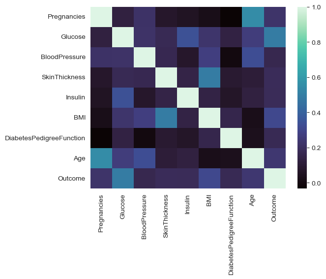

```python
sns.heatmap(data.corr(),cmap='mako')
```

### MODELS

```python
from sklearn.preprocessing import StandardScaler
sc_X = StandardScaler()
X =  pd.DataFrame(sc_X.fit_transform(data.drop(["Outcome"],axis = 1),),
        columns=['Pregnancies', 'Glucose', 'BloodPressure', 'SkinThickness', 'Insulin',
       'BMI', 'DiabetesPedigreeFunction', 'Age'])
```

```python
y=data.Outcome
```

```python
#splitting the dataset
from sklearn.model_selection import train_test_split
X_train,X_test,Y_train,Y_test = train_test_split(X,y,test_size=.30,random_state=3)
```

### LOGISTIC REGRESSION

◈ Logistic regression aims to solve classification problems. It does this by predicting categorical outcomes, unlike linear regression that predicts a continuous outcome.  
◈ In the simplest case there are two outcomes, which is called binomial, an example of which is predicting if a tumor is malignant or benign. Other cases have more than two outcomes to classify, in this case it is called multinomial.  
In our dataset, the main objective is to study whether a person has Diabetes or not.Therefore outcomes are either 0 or 1 and hence Logistic Regression model can be used.

```python
from sklearn.linear_model import LogisticRegression
log_reg = LogisticRegression(C=1,penalty='l2')
log_reg.fit(X_train,Y_train)

log_acc=accuracy_score(Y_test,log_reg.predict(X_test))


print("Train Set Accuracy:"+str(accuracy_score(Y_train,log_reg.predict(X_train))*100))
print("Test Set Accuracy:"+str(accuracy_score(Y_test,log_reg.predict(X_test))*100))
```

```
Train Set Accuracy:78.58472998137802
Test Set Accuracy:74.02597402597402
```

```python
print(classification_report(Y_test,log_reg.predict(X_test)))
print("Precision:",metrics.precision_score(Y_test,log_reg.predict(X_test)))
print('F1 score:',metrics.f1_score(Y_test,log_reg.predict(X_test)))
print('Recall:',metrics.recall_score(Y_test,log_reg.predict(X_test)))
```

```
              precision    recall  f1-score   support

           0       0.73      0.88      0.80       133
           1       0.77      0.55      0.64        98

    accuracy                           0.74       231
   macro avg       0.75      0.72      0.72       231
weighted avg       0.75      0.74      0.73       231

Precision: 0.7714285714285715
F1 score: 0.6428571428571429
Recall: 0.5510204081632653
```

### RANDOM FOREST CLASSIFIER

◈ Random Forest is a popular machine learning algorithm that belongs to the supervised learning technique. It can be used for both Classification and Regression problems in ML. It is based on the concept of ensemble learning, which is a process of combining multiple classifiers to solve a complex problem and to improve the performance of the model.  
◈ As the name suggests, "Random Forest is a classifier that contains a number of decision trees on various subsets of the given dataset and takes the average to improve the predictive accuracy of that dataset." Instead of relying on one decision tree, the random forest takes the prediction from each tree and based on the majority votes of predictions, and it predicts the final output.

```python
from sklearn.ensemble import RandomForestClassifier
rfc = RandomForestClassifier()
rfc.fit(X_train,Y_train)

rfc_acc = accuracy_score(Y_test,rfc.predict(X_test))
rfc_train=accuracy_score(Y_train,rfc.predict(X_train))

print("Train Set Accuracy:"+str(accuracy_score(Y_train,rfc.predict(X_train))*100))
print("Test Set Accuracy:"+str(accuracy_score(Y_test,rfc.predict(X_test))*100))
```

```
Train Set Accuracy:100.0
Test Set Accuracy:70.995670995671
```

```python
print(classification_report(Y_test,rfc.predict(X_test)))
print("Precision:",metrics.precision_score(Y_test,rfc.predict(X_test)))
print('F1 score:',metrics.f1_score(Y_test,rfc.predict(X_test)))
print('Recall:',metrics.recall_score(Y_test,rfc.predict(X_test)))
```

```
              precision    recall  f1-score   support

           0       0.71      0.85      0.77       133
           1       0.72      0.52      0.60        98

    accuracy                           0.71       231
   macro avg       0.71      0.69      0.69       231
weighted avg       0.71      0.71      0.70       231

Precision: 0.7183098591549296
F1 score: 0.6035502958579881
Recall: 0.5204081632653061
```

### DECISION TREE CLASSIFIER

◈Decision Tree is a Supervised learning technique that can be used for both classification and Regression problems, but mostly it is preferred for solving Classification problems. It is a tree-structured classifier, where internal nodes represent the features of a dataset, branches represent the decision rules and each leaf node represents the outcome.It is a graphical representation for getting all the possible solutions to a problem/decision based on given conditions.  
◈ There are various algorithms in Machine learning, so choosing the best algorithm for the given dataset and problem is the main point to remember while creating a machine learning model. Below are the two reasons for using the Decision tree:  
▸ Decision Trees usually mimic human thinking ability while making a decision, so it is easy to understand.  
▸ The logic behind the decision tree can be easily understood because it shows a tree-like structure.

```python
from sklearn.tree import DecisionTreeClassifier

dtc = DecisionTreeClassifier(criterion='entropy',max_depth=5)
dtc.fit(X_train, Y_train)


dtc_acc= accuracy_score(Y_test,dtc.predict(X_test))

print("Train Set Accuracy:"+str(accuracy_score(Y_train,dtc.predict(X_train))*100))
print("Test Set Accuracy:"+str(accuracy_score(Y_test,dtc.predict(X_test))*100))
```

```
Train Set Accuracy:83.24022346368714
Test Set Accuracy:71.86147186147186
```

```python
print(classification_report(Y_test,dtc.predict(X_test)))
print("Precision:",metrics.precision_score(Y_test,dtc.predict(X_test)))
print('F1 score:',metrics.f1_score(Y_test,dtc.predict(X_test)))
print('Recall:',metrics.recall_score(Y_test,dtc.predict(X_test)))
```

```
              precision    recall  f1-score   support

           0       0.72      0.86      0.78       133
           1       0.74      0.54      0.62        98

    accuracy                           0.72       231
   macro avg       0.73      0.70      0.70       231
weighted avg       0.73      0.72      0.71       231

Precision: 0.7361111111111112
F1 score: 0.623529411764706
Recall: 0.5408163265306123
```

## COMPARISION OF MODELS

The Accuracy scores of each of the tested and trained models are compared using a barplot below.

### ACCURACY SCORES OF TRAINED MODELS

```python
Trained_models = pd.DataFrame({
    'Train_Model': ['Logistic','Random Forest Classifier', 'Decision Tree Classifier'],
    'Train_Score': [ log_train,rfc_train,dtc_train] })

Trained_models.sort_values(by = 'Train_Score', ascending = False)
```

|  | Train_Model | Train_Score |
| --- | --- | --- |
| 1 | Random Forest Classifier | 1.000000 |
| 2 | Decision Tree Classifier | 0.832402 |
| 0 | Logistic | 0.785847 |

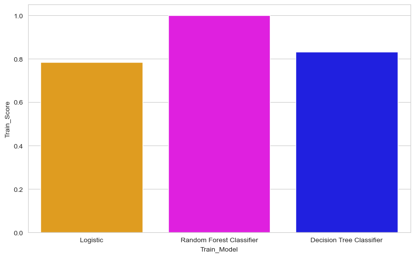

```python
colors = ["orange", "magenta","blue"]

sns.set_style("whitegrid")
plt.figure(figsize=(10,6))
plt.ylabel("Accuracy %")
plt.xlabel("Algorithms")
sns.barplot(x=Trained_models['Train_Model'],y=Trained_models['Train_Score'], palette=colors )
plt.show()
```

### ACCURACY SCORES OF TESTED MODELS

```python
Tested_models = pd.DataFrame({
    'Test_Model': ['Logistic','Random Forest Classifier', 'Decision Tree Classifier'],
    'Test_Score': [ log_acc,rfc_acc,dtc_acc] })

Tested_models.sort_values(by = 'Test_Score', ascending = False)
```

|  | Test_Model | Test_Score |
| --- | --- | --- |
| 0 | Logistic | 0.740260 |
| 2 | Decision Tree Classifier | 0.718615 |
| 1 | Random Forest Classifier | 0.709957 |

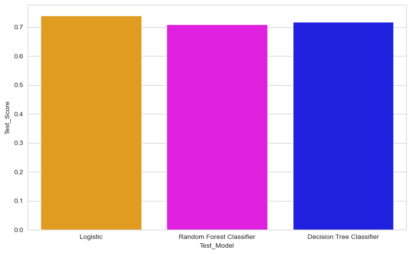

```python
colors = ["orange", "magenta","blue"]

sns.set_style("whitegrid")
plt.figure(figsize=(10,6))
plt.ylabel("Accuracy %")
plt.xlabel("Algorithms")
sns.barplot(x=Tested_models['Test_Model'],y=Tested_models['Test_Score'], palette=colors )
plt.show()
```

### CONCLUSION

- **Insufficient data:** One of the most common causes of low accuracy is having insufficient data to train the model. This can happen if the dataset is too small. In this case, the model may not have enough information to learn from which can lead to low accuracy.
- **Lack of feature engineering:**Feature engineering is the process of selecting and designing features for a machine learning model. If the features used to train the model are not well designed or relevant, the model may have difficulty learning from the data and may have low accuracy.